# Six-Sigma Project: Production of phones at PhoneNow

Alexander, Rodrigo and Johannes

31 desember, 2021

# 1 Background

PhoneNow is a small technology company, especially known for producing high quality phones at a low cost. Their business strategy is based on selling good quality phones to the low-end market. In this way they avoid the large market shares of Apple and Samsung in the luxury phone market. Their main competitors are Xiaomi, Nokia and Moto, among others. Moreover, they only sell products directly from their own website, and the products are made on-demand. In this way, their business does not require large amounts of capital, since they use capital they get directly from each customer for their costs. Also, they guarantee a production (and delivery) time of maximum 30 days, i.e. the customer should have their phone in their hand within 30 days. PhoneNow also guarantees customer satisfaction when it comes to the quality of the phone; if the phone is not to the quality that the customer expects, PhoneNow will make a new phone for the respective customer.

Their business has been very successful the last couple of years, with market shares growing. However, the last two months they have received more complaints on production time and quality of their products than usual. This is why the Six-Sigma will be employed, with the goal of resolving some of the issues. The initial project was to reduce the number of complaints from the customers, both when it comes to production time and quality of the products.

The Steering Committee estimated that the percentage of unsatisfied customers because of long production time with lower quality than expected was between 10% and 15%. A maximum level equal to 3% was deemed as acceptable.

A team of 2 managers was launched, led by a Black Belt (BB), formed in the UPC.

# 2 Definition

## 2.1 Project Charter

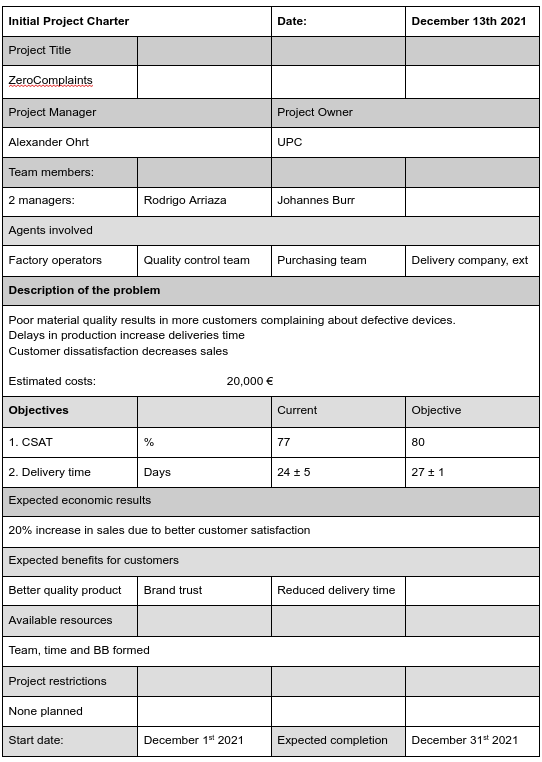

## 2.2 SIPOC scheme

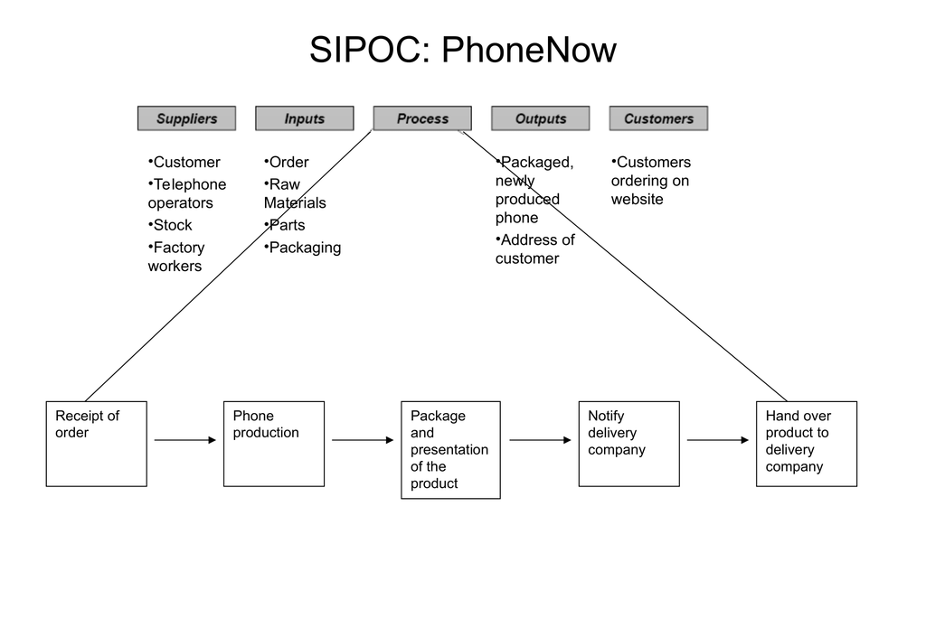

**Figure:** SIPOC diagram

## 2.3 CTx

### 2.3.1 CTQ

The critical-to-quality (CTQ) target is that less than 2% of the customers should be unsatisfied with the product they receive. Moreover, a critical-to-time (CTT) target is that less than 5% of the customers should receive their product at a delayed time.

### 2.3.2 VoC

Using a survey published on our social media we:

- Confirmed and quantified what had already been discovered
- Found issues related to the quality of the phones (e.g. discovered general issues in quality, parts that are faulty more often than others, issues in packaging, etc.)

## 2.4 Business Case

The annual turnover of PhoneNow digital shop is 100,000 €.

The 15% of delayed production decreases the customer satisfaction by 20%.

It has been estimated that clients with a customer satisfaction below 6 will not buy a phone again from the company. This client churn results in losses of 20,000 €.

The estimations have been validated by the finance director.

# 3 Measure

## 3.1 Questions to Answer

- How long does it take from order to shipment?
- How long does it take from shipment to delivery?
- How long does it take for a customer to receive his mobile device after he has finished the purchase?
- What percentage of clients file a complaint because of defective devices?

## 3.2 Review Existing Data - Exploratory Data Analysis

The existing data for this business is simulated.

```r
set.seed(1)
N=1000
# Production time.
t_to_ship = rexp(N,1/2) + rnorm(N,15,2)

# Shipment time.
t_ship = rexp(N,1/2) + rnorm(N,5,3)

total_times <- t_to_ship + t_ship
mu_tot <- mean(total_times)
sigma_tot <- sd(total_times)
```

### 3.2.1 Delivery Times

We have data from 1000 customers during the last two months. The company provided us with production times and shipping times. The production times were collected by PhoneNow themselves, whereas the shipping times were collected by a third-party shipping company that PhoneNow has hired. The total time the customer has to wait for the product after placing an order is the sum of these two times.

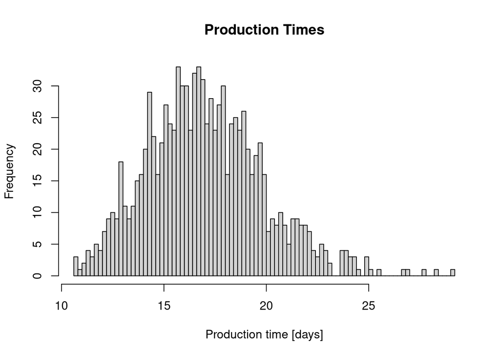

```r
hist(t_to_ship, main = "Production Times", xlab = "Production time [days]", breaks = 100)
```

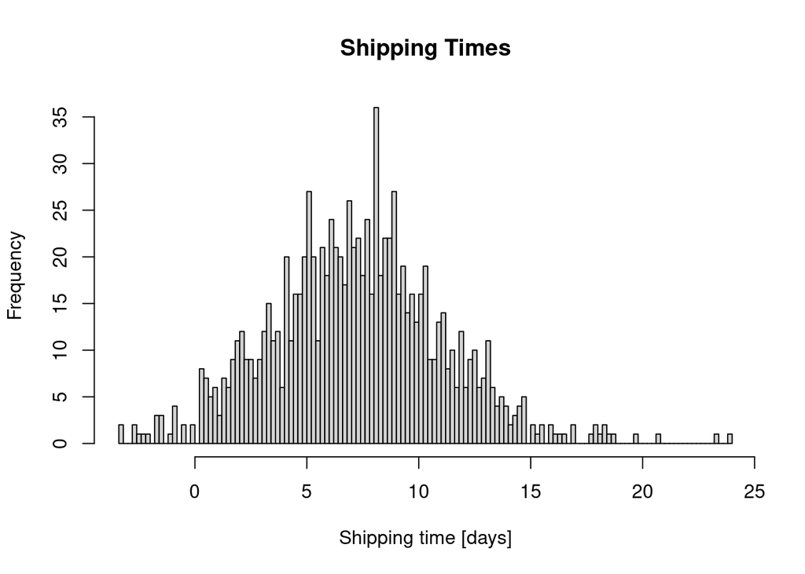

```r
hist(t_ship, main = "Shipping Times", xlab = "Shipping time [days]", breaks = 100)
```

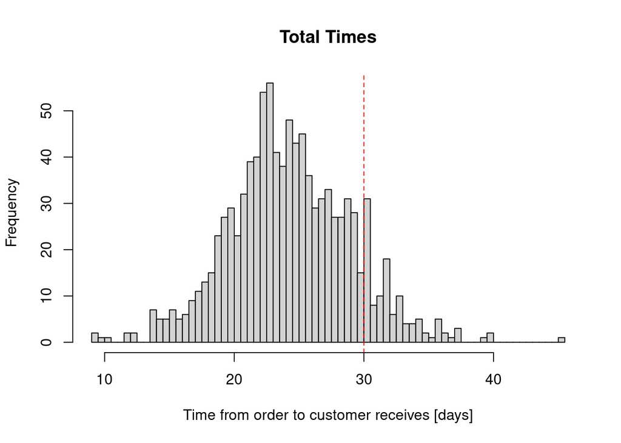

```r
hist(total_times, main = "Total Times", xlab = "Time from order to customer receives [days]", breaks = 100)
abline(v = 30, col = "red", lty = 2)
```

A red dotted line is plotted to show where the guaranteed time is exceeded. The mean of the total time is 24.29 and the standard error is 4.69.

#### 3.2.1.1 Six-Sigma Analysis and Control Chart

We want to check if the process is a Six-Sigma process. The process is assumed to be optimal if the total time until the customer receives the product is distributed as $N(27, 1)$.

```r
sigma_opt <- sqrt(1)
mu_opt <- 27
LSL <- (-6) * sigma_opt + mu_opt
USL <- 6 * sigma_opt + mu_opt
faults<-sum((total_times>USL)+(total_times<LSL))
```

The bounds LSL and USL in the Six-Sigma environment are calculated to being 21 and 33, respectively. Moreover, the number of faults in the total times is 256, which means that the proportion of faults is 0.26. Note that this shows that the estimations given by the Steering Committed from earlier are severely underestimated. This means that the observed process has 2.56^{5} faults per million, i.e. it is a 2 sigma process and it is clearly out-of-control. This was determined from the Sigma Scale table. However, it can also be calculated that this is a 2 sigma process, as done in the code block below.

```r
prob<-faults/N
(k<-qnorm(1-prob,1.5,1))
```

```
## [1] 2.155727
```

A visualization is shown below.

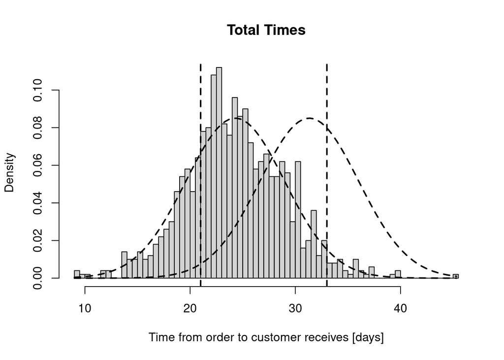

```r
x <- seq(min(total_times), max(total_times), length = 100)
f1 <- dnorm(x, mean = mu_tot+1.5*sigma_tot, sd = sigma_tot)
f2 <- dnorm(x, mean = mu_tot, sd = sigma_tot)
hist(total_times,main = "Total Times", xlab = "Time from order to customer receives [days]",
     breaks = 100, probability = T)
lines(x,f1,type="l",lwd=2,lty=2)
lines(x,f2,type="l",lwd=2,lty=2)
abline(v=LSL,lwd=2,lty=2)
abline(v=USL,lwd=2,lty=2)
```

```r
DPMO<-1000000*(1-pnorm(USL,mu_tot+1.5*sigma_tot,sigma_tot))
DPMO
```

The dotted vertical lines in the plot above show the bounds LSL and USL. The control chart above also clearly shows that the process is not Six-Sigma, since there are times that are above USL and below LSL. Note that the times below LSL is not a problem when it comes to customer satisfaction, but it is a problem for PhoneNow, because it means that the variability in the production and shipping times is too large and they are not maximizing the potential returns in the company. The long term DPMO is 3.6074743^{5}, which is large.

```r
sigma<-(USL-mu_tot)/6
sigma
```

```
## [1] 1.451499
```

```r
DPMO<-1000000*(1-pnorm(USL,mu_tot+1.5*sigma,sigma))
DPMO
```

```
## [1] 3.397673
```

```r
Cp_opt<-(USL-LSL)/(6*sigma_opt)
Cp<-(USL-LSL)/(6*sigma_tot)
```

In order to change the process to a Six-Sigma process, we need to reduce the standard deviation of the process from 4.69 to 1.45. Note also that the optimal production capacity index is 2, whereas the observed production capacity index is only 0.43.

Next we want to see if the process is out-of-control according to a Six-Sigma criterion. Below, two different X Control Charts are plotted. The first shows the X Chart when we assume the same optimal process as above, $N(27, 1)$. The second X Chart is a chart where we assume that the target values are not known (which is more general than assuming the optimal normal process). The first 300 data points are used to estimate the mean and the standard deviation of the process, while the remaining 700 data points are used to measure the process. Both the charts have Six-Sigma upper and lower limits.

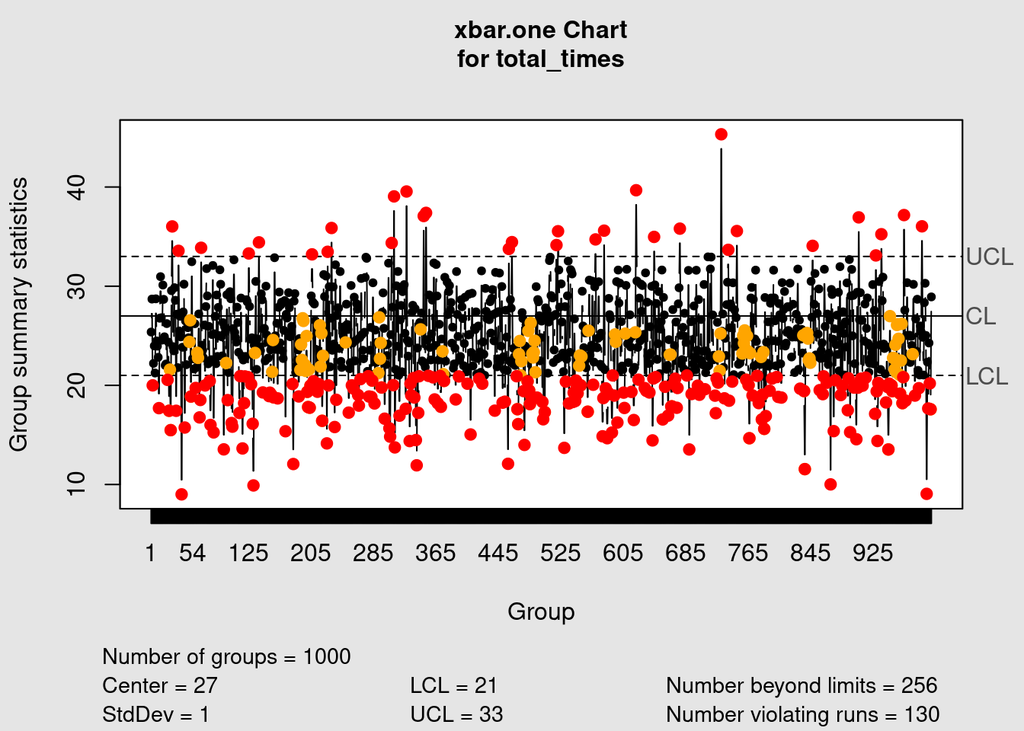

```r
qcc(total_times, type = "xbar.one", center = 27, std.dev = 1, nsigma = 6)
```

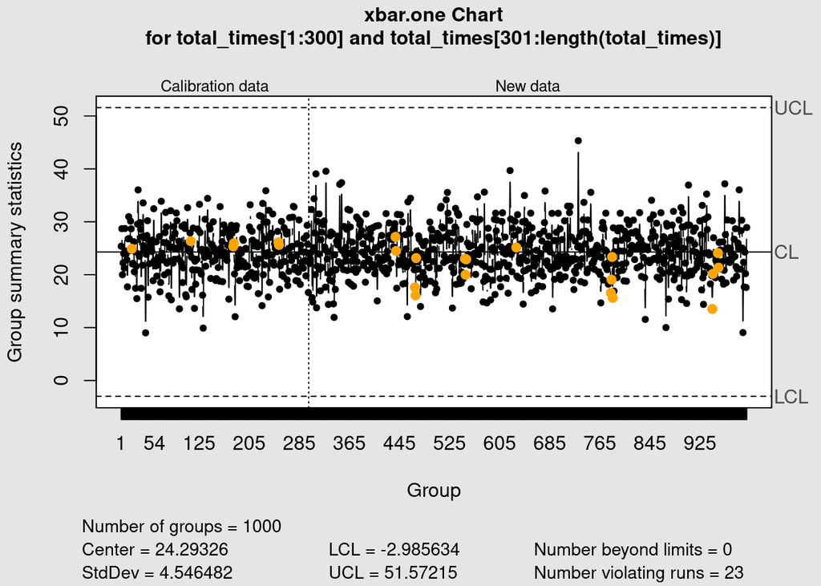

```r
qcc(total_times[1:300], type = "xbar.one", newdata = total_times[301:length(total_times)], nsigmas = 6)
```

From the first chart we gain the same conclusion as earlier, namely that the process is quite clearly out-of-control with the Six-Sigma criterion. However, the second chart shows that the process is not out-of-control when not assuming an optimal distribution of the data. Perhaps this second approach indeed would make more sense, because what is the reason for the assumed optimal process? How can one know that the times should be distributed this way? In most cases one could not know this. Despite the slightly artificial definition of the optimal process as $N(27, 1)$, we will study this on new data after some proposed improvements also, as a way to quantify if the process has been improved, i.e. if the process has become more similar to the optimal process or not. Lastly, we would argue that the optimal process we have defined is in fact a very good distribution of times, because we know that $99.7\%$ of all data from a normal distribution lies within 3 standard deviations of the mean, which for the optimal process would mean that (for many customers) only $0.3\%$ of the customers get their phone too late, while PhoneNow can deliver their phones as late as possible before the guarantee of 30 days is violated, saving them costs as well. Perhaps the optimal process is a bit optimistic, but it is still a reasonable goal to work towards for the company.

### 3.2.2 Customer Satisfaction

In discussion between managers and statisticians it was defined that satisfaction should be measured between zero and one hundred. Through an online tool recent customers were asked to provide their satisfaction assessment to various items, whose scores where then averaged. This average justifies the choice of a normal distribution via the central limit theorem. The managers defined the customer satisfaction as acceptable when it is distributed as $N(80, 10)$. Below the observed satisfaction data is displayed.

```r
set.seed(2022)
sigma_optj <- sqrt(10)
mu_optj <- 80
LSL2 <- (-6) * sigma_optj + mu_optj
Nj=500
satisfaction = rnorm(N,80-3,sqrt(10)+2+rnorm(1,0,2))
satisfaction[satisfaction>100]=runif(1,90,100)
faultsj<-sum((satisfaction<LSL2))
faultsj
```

```
## [1] 8
```

```r
faultsj/Nj
```

```
## [1] 0.016
```

```r
probj<-faultsj/Nj
(kj<-qnorm(1-probj,1.5,1))
```

```
## [1] 3.644411
```

A visualization is shown below.

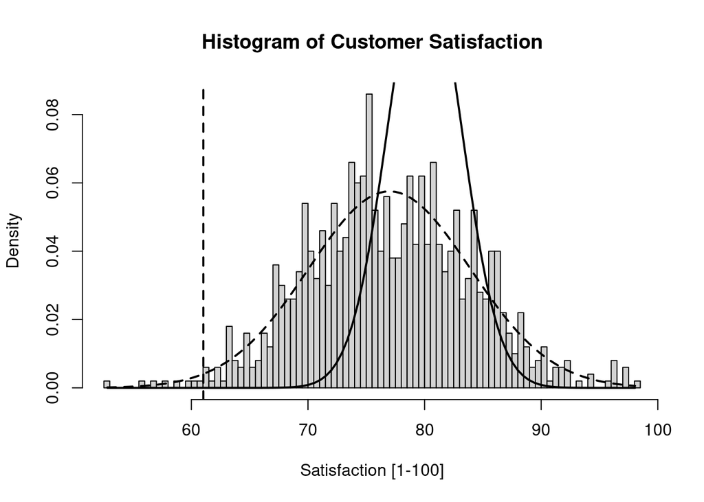

```r
mu2 <- mean(satisfaction)
sigma2 <- sd(satisfaction)
xj <- seq(min(satisfaction), max(satisfaction), length = 100)
f1j <- dnorm(xj, mean = mu_optj, sd = sigma_optj)
f2j <- dnorm(xj, mean = mu2, sd = sigma2)
hist(satisfaction,main = "Histogram of Customer Satisfaction", xlab = "Satisfaction [1-100]",
     breaks = 100, probability = T)
lines(xj,f1j,type="l",lwd=2,lty=1)
lines(xj,f2j,type="l",lwd=2,lty=2)
abline(v=LSL2,lwd=2,lty=2)
```

The dotted vertical line shows the threshold under which a customer satisfaction is considered as a fault. In fact only 8 faults are observed. The thick Gaussian shows the optimal process, while the dotted Gaussian shows the normal distribution with parameters estimated from the data. It is apparent that the process is very different from the optimal Gaussian process.

## 3.3 Proposed Improvements

- Talk to the employees: Are they overworked? Do they not enjoy their work or the workplace? Team building?
- Talk to the delivery company: Are they not doing their jobs to the best of their ability?
- Change delivery company
- Change supplier of parts

## 3.4 Collect New Data After the Proposed Improvements

### 3.4.1 Delivery Times

New data are “collected” (simulated) after testing the proposed improvements for 2 months. PhoneNow have decided to test using two different shipping companies, where they are hired to deliver half of the orders each. This is in order to mitigate the large variation seen in the shipping times from the original data.

```r
set.seed(1)
N2 = 800 # A bit fewer orders than we had during the first two months.

##### Data for production and shipping times.
# Production time.
t_to_ship_2 = rnorm(N2,23,1)

# two companies are used. maybe there's a difference
t_ship_comp1 <- rexp(N2/2,1/0.5) + rnorm(N2/2,2,1)
t_ship_comp2 = rexp(N2/2,1/1) + rnorm(N2/2, 3,3)

total_time = t_to_ship_2 + c(t_ship_comp1,t_ship_comp2)
# company1 shipped the 1st half of phones, comp2 the 2nd
```

Now we have collected 800 orders. The new production, shipment (for both companies) and total times are shown in the histograms below.

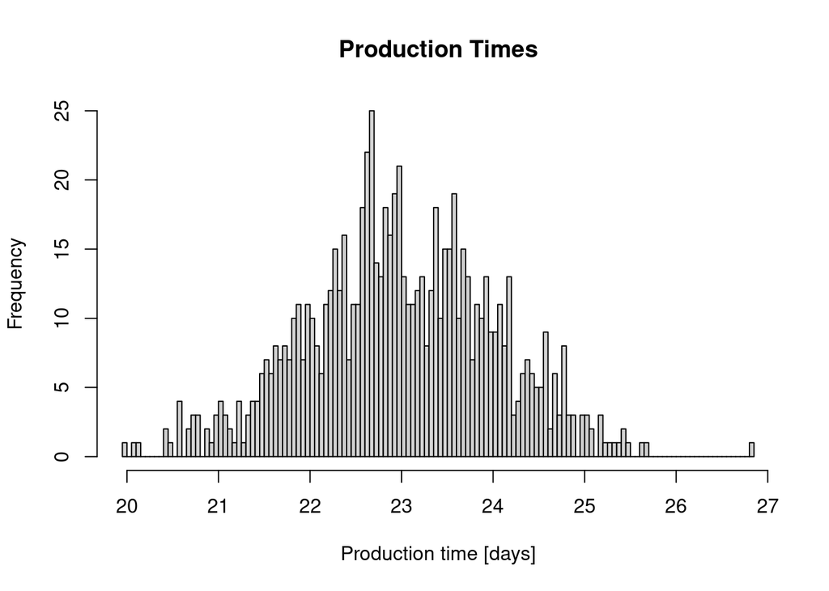

```r
hist(t_to_ship_2, main = "Production Times", xlab = "Production time [days]", breaks = 100)
```

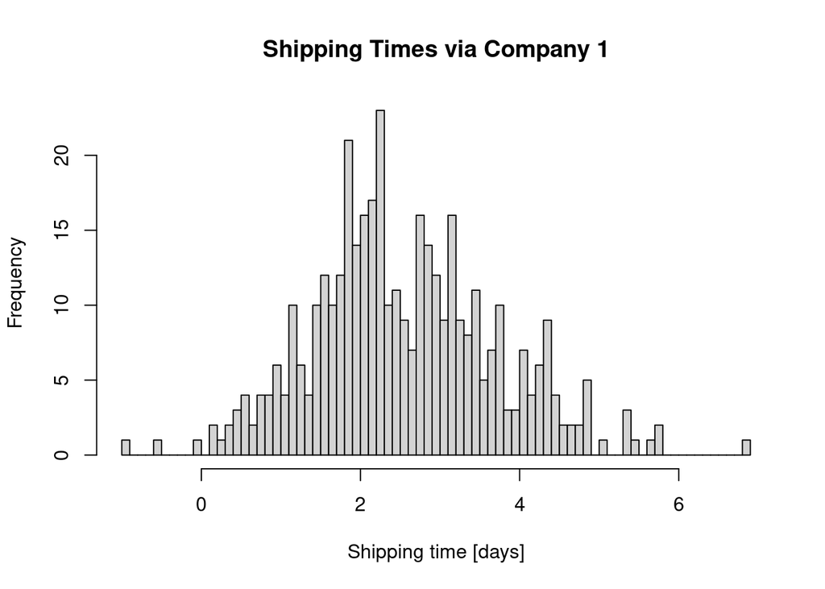

```r
hist(t_ship_comp1, main = "Shipping Times via Company 1", xlab = "Shipping time [days]", breaks = 100)
```

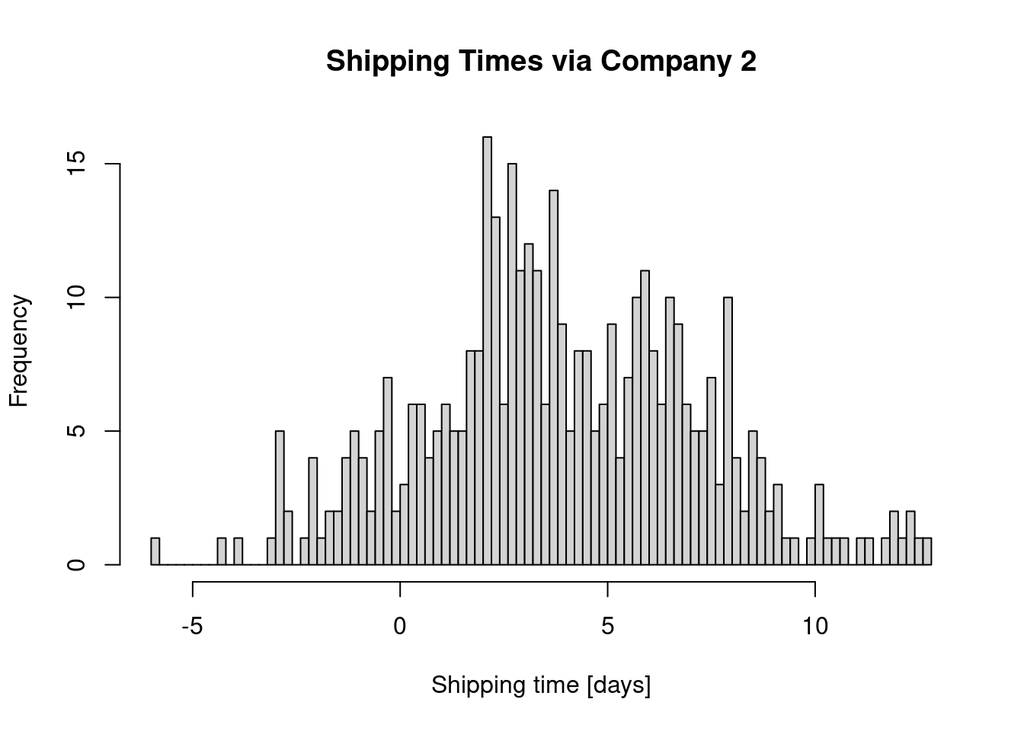

```r
hist(t_ship_comp2, main = "Shipping Times via Company 2", xlab = "Shipping time [days]", breaks = 100)
```

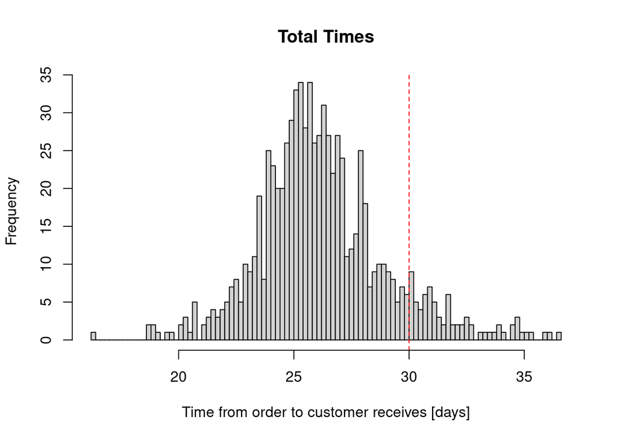

```r
hist(total_time, main = "Total Times", xlab = "Time from order to customer receives [days]", breaks = 100)
abline(v = 30, col = "red", lty = 2)
```

# 4 Experiment Design - Do the Improvements Work?

The experiment we are doing to test the proposed improvements work is using the two following factors

1. Compare two different delivery company’s shipment-to-delivery times
2. Compare % defective phones by different screen glass supplier

## 4.1 Testing Delivery Companies

Let’s compare both shipment companies to see if we should prefer one over the other.

```r
wilcox.test(t_ship_comp1,t_ship_comp2)
```

```
##
##  Wilcoxon rank sum test with continuity correction
##
## data:  t_ship_comp1 and t_ship_comp2
## W = 56839, p-value = 1.371e-12
## alternative hypothesis: true location shift is not equal to 0
```

```r
median(t_ship_comp1) < median(t_ship_comp2)
```

```
## [1] TRUE
```

In fact there is a significant difference between the delivery time of both companies. If possible, commissioning the first should be preferred. Since we had time on our hands, PhoneNow agreed to collect data for one more month after this test, only using the first shipping company in the test from above.

```r
set.seed(1)
N3 = 1100 # A bit fewer orders than we had during the first two months.

##### Data for production and shipping times.
# Production time.
t_to_ship_3 = rnorm(N3,23,1)

# two companies are used. maybe there's a difference
t_ship_com_final <- rexp(N3/2,1/0.5) + rnorm(N3/2,2,1.5)

total_time_final = t_to_ship_3 + t_ship_com_final
mu_tot_final <- mean(total_time_final)
sigma_tot_final <- sd(total_time_final)
```

This time, 1100 orders were collected. The new data is visualized below. The mean of the total times is 25.48 and the standard error is 1.97.

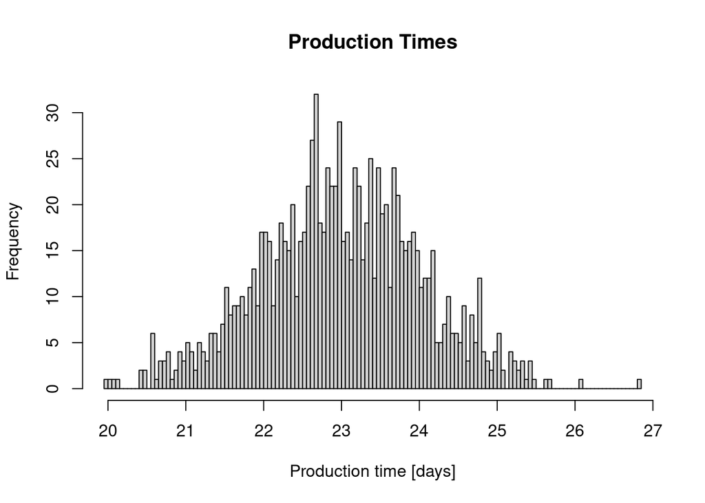

```r
hist(t_to_ship_3, main = "Production Times", xlab = "Production time [days]", breaks = 100)
```

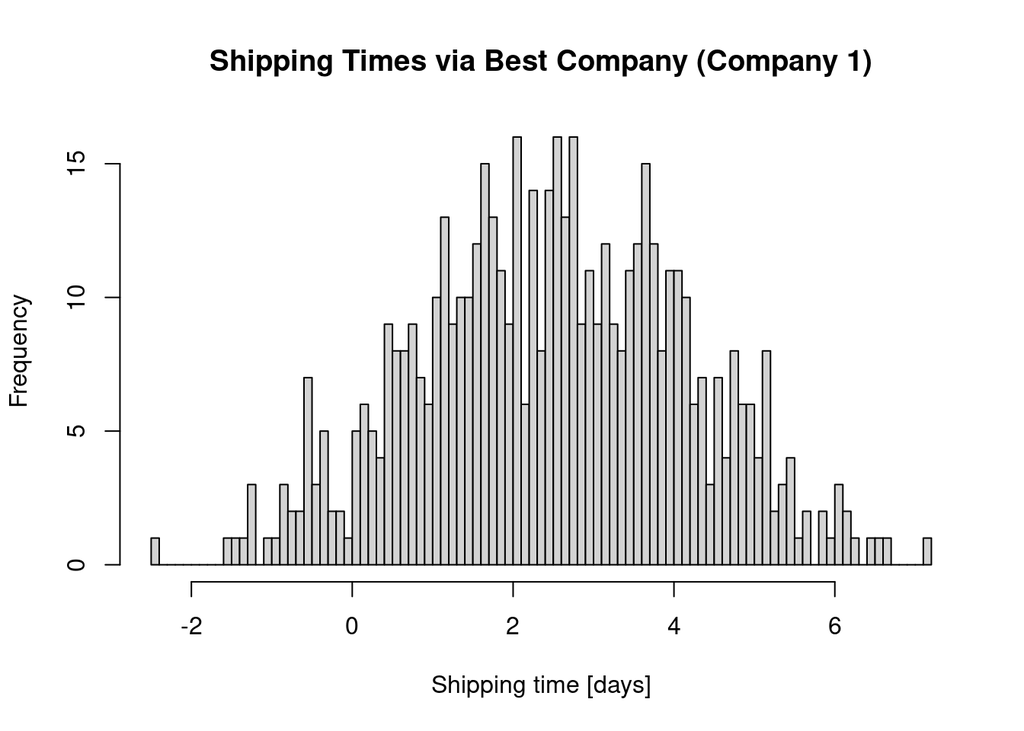

```r
hist(t_ship_com_final, main = "Shipping Times via Best Company (Company 1)", xlab = "Shipping time [days]", breaks = 100)
```

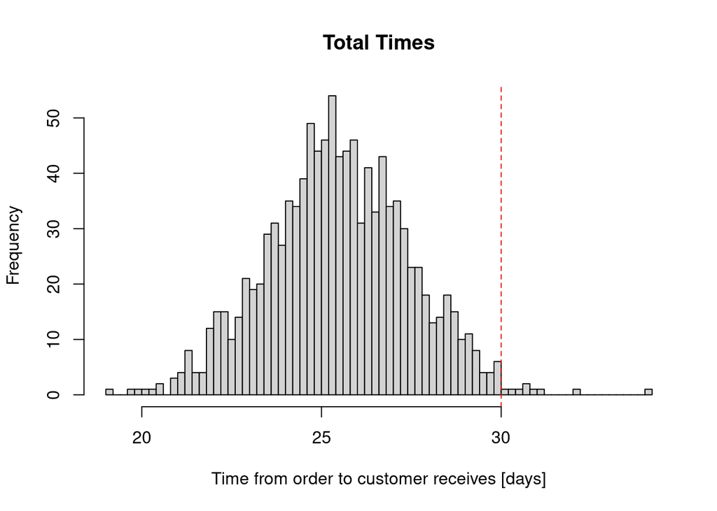

```r
hist(total_time_final, main = "Total Times", xlab = "Time from order to customer receives [days]", breaks = 100)
abline(v = 30, col = "red", lty = 2)
```

## 4.2 Testing Defective Phones by 3x2 Different Material Suppliers

```r
set.seed(420)

# first simulate latent quality variables
q_gorilla = rnorm(N,0.8,0.2)
q_special = rnorm(N,0.85,0.1)
q_simple  = rnorm(N,0.77,0.3)


q_touch1 = rnorm(0.9,0.11)
q_touch2 = rnorm(0.8,0.25)

q_gorilla[q_gorilla < 0] <- q_special[q_special<0] <- q_simple[q_simple<0] <- 0
q_gorilla[q_gorilla > 1] <- q_special[q_special>1] <- q_simple[q_simple>1] <- 1
q_touch1[q_touch1<0] <- q_touch2[q_touch2<0] <- 0
q_touch1[q_touch1>1] <- q_touch2[q_touch2>1] <- 1

#init
phones_working = vector('numeric',6)
M = 150 #each of the 6 cells gets 150 datapoints

for (i in 1:6){
  phones_working = sum( rbinom(M,1,q_touch1[1:M]) * rbinom(M,1,q_gorilla[1:M]))
}

# simulate customer sat as a function of delivery times and glass quality
csat.sim <- function() {
  gorilla.sample <- sample(q_gorilla, 334)
  special.sample <- sample(q_special, 333)
  simple.sample <- sample(q_simple, 333)
  df <- data.frame(list(total_t=total_times,
                        glass=c(rep('gorilla',334), rep('special',333),rep('simple',333)),
                        quality=c(gorilla.sample, special.sample, simple.sample)
                        ))
  df$csat <- -0.1*df$total_t + 10*df$quality + 1.5 # time decreases csat, quality increases it
  df$csat <- round((df$csat / max(df$csat)) * 10)
  df$csat[df$csat <0] <- 0
  #summary(df$csat)
  return(df)
}
```

```r
set.seed(420)
total = 75
likert_scale = vec=c(-Inf,-30,-20,-10,10,20,30,Inf)


s_gor_t1  = findInterval(rnorm(total,18.5,15),likert_scale)
s_gor_t2  = findInterval(rnorm(total,27,15),likert_scale)
s_spec_t1 = findInterval(rnorm(total,26,15),likert_scale)
s_spec_t2 = findInterval(rnorm(total,18.5,15),likert_scale)
s_simp_t1 = findInterval(rnorm(total,0,15),likert_scale)
s_simp_t2 = findInterval(rnorm(total,-10,15),likert_scale)

M=total
sat = c(s_gor_t1,s_gor_t2,s_spec_t1,s_spec_t2,s_simp_t1,s_simp_t2)
glass = c(rep(1,M),rep(1,M),rep(2,M),rep(2,M),rep(3,M),rep(3,M))
touch = c(rep(1,M),rep(2,M),rep(1,M),rep(2,M),rep(1,M),rep(2,M))

anov_data = data.frame(sat,as.factor(glass),as.factor(touch))
colnames(anov_data) = c("satisfaction","glass","touchscreen")


summary(aov(sat~glass*touch,data=anov_data))
```

```
##              Df Sum Sq Mean Sq F value   Pr(>F)
## glass         2  258.6  129.31  98.423  < 2e-16 ***
## touch         1    8.5    8.54   6.502   0.0111 *
## glass:touch   2   40.0   20.00  15.225 4.03e-07 ***
## Residuals   444  583.3    1.31
## ---
## Signif. codes:  0 '***' 0.001 '**' 0.01 '*' 0.05 '.' 0.1 ' ' 1
```

As we can see both main effects for the glass and the touch screen technology processed as well as the interaction effect are statistically significant on a 5% level. Therefore the null hypothesis that these differences do not exist in the population can be rejected. Let’s visually see, where these difference are, in order to conclude business recommendations.

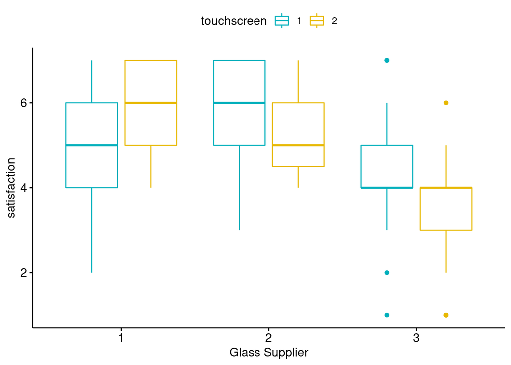

```r
ggboxplot(anov_data, x = "glass", y = "satisfaction",
          color = "touchscreen",
          palette = c("#00AFBB", "#E7B800"),
          xlab="Glass Supplier")
```

# 5 Does the New Process Meet the Six-Sigma Criteria?

## 5.1 Delivery Times

As earlier, we want to check if the process is Six-Sigma and if it is out-of-control using the Six-Sigma criterion. The process is still assumed to be optimal if the total time until the customer receives the product is distributed as $N(27, 1)$.

```r
faults2<-sum((total_time_final>USL)+(total_time_final<LSL))
```

Here we use the final data with 1100 orders, where only the delivery company that was judged as the best was used. The total faults in the new process, when it comes to total times, is 11, which means that the proportion of faults is 0.01. This means that the observed process has 10^{4} faults per million, i.e. it is a $\sim$ 4 sigma process and it is clearly out-of-control. This was determined from the Sigma Scale table. However, it can also be calculated that this is a $\sim$ 4 sigma process, as done in the code block below.

```r
prob2<-faults2/N3
(k2<-qnorm(1-prob2,1.5,1))
```

```
## [1] 3.826348
```

This is clearly an improvement compared to the original process, but it is still not a Six-Sigma process. A visualization is given below.

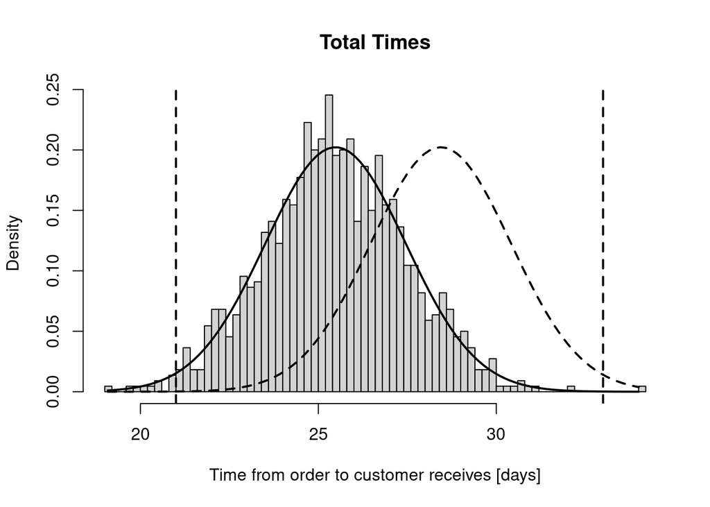

```r
x2 <- seq(min(total_time_final), max(total_time_final), length = 100)
f11 <- dnorm(x2, mean = mu_tot_final+1.5*sigma_tot_final, sd = sigma_tot_final)
f21 <- dnorm(x2, mean = mu_tot_final, sd = sigma_tot_final)
hist(total_time_final,main = "Total Times", xlab = "Time from order to customer receives [days]",
     breaks = 100, probability = T)
lines(x2,f11,type="l",lwd=2,lty=2)
lines(x2,f21,type="l",lwd=2,lty=1)
abline(v=LSL,lwd=2,lty=2)
abline(v=USL,lwd=2,lty=2)
```

```r
DPMO<-1000000*(1-pnorm(USL,mu_tot_final+1.5*sigma_tot_final,sigma_tot_final))
```

The visualization above also shows that the process is not Six-Sigma, since there are times that are above USL and below LSL. The long term DPMO is 1.0423896^{4}, which is an improvement compared to earlier.

```r
sigma<-(USL-mu_tot_final)/6
sigma
```

```
## [1] 1.25277
```

```r
DPMO<-1000000*(1-pnorm(USL,mu_tot_final+1.5*sigma,sigma))
DPMO
```

```
## [1] 3.397673
```

```r
Cp_opt<-(USL-LSL)/(6*sigma_opt)
Cp<-(USL-LSL)/(6*sigma_tot_final)
```

In order to change the process to a Six-Sigma process, we need to reduce the standard deviation of the process from 1.97 to 1.25. Again, note that the observed production capacity index is 1.01, which is an improvement compared to earlier.

As before collecting new data, two control charts are plotted, in order to check if the process is out-of-control.

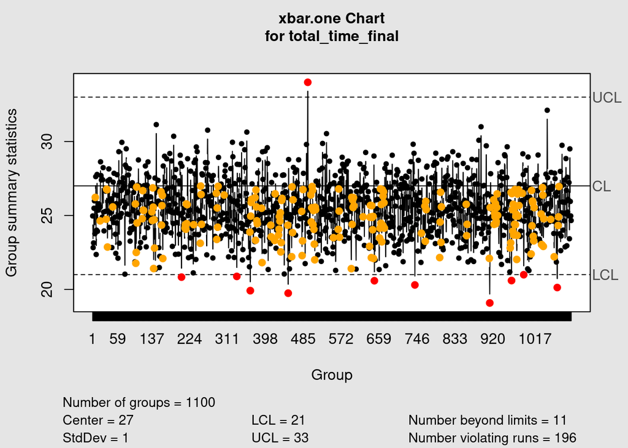

```r
qcc(total_time_final, type = "xbar.one", center = 27, std.dev = 1, nsigma = 6)
```

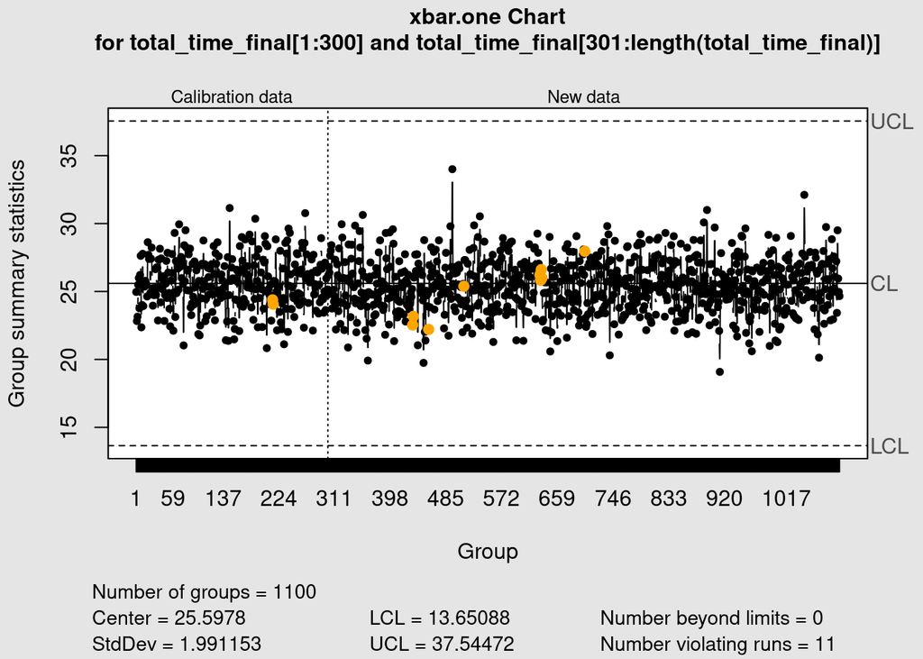

```r
qcc(total_time_final[1:300], type = "xbar.one", newdata = total_time_final[301:length(total_time_final)], nsigmas = 6)
```

The first control chart shows fewer points beyond the limits, but a larger number of violating runs. It is not clear why this is the case, but it should be investigated further. In the second control chart, there are still no points beyond the limits, and the number of violating runs are fewer than earlier. Also, it is apparent that the estimated center and standard deviation of the process is closer to the optimal process, which means that the improvements have worked, at least when the goal is to make the process more similar to a $N(27, 1)$.

## 5.2 Customer Satisfaction Data

Customer Satisfaction was again measured after all improvement raised in this report were implemented.

```r
set.seed(4)
satisfaction = rnorm(Nj,80-rnorm(1,-1,1),sqrt(10)+runif(1,0,2))
satisfaction[satisfaction>100]=runif(1,90,100)
faultsj<-sum((satisfaction<LSL2))
faultsj/Nj
```

```
## [1] 0
```

In fact in this data from 500 customers zero faults are observed. Let’s visualize the process compared to the optimal one.

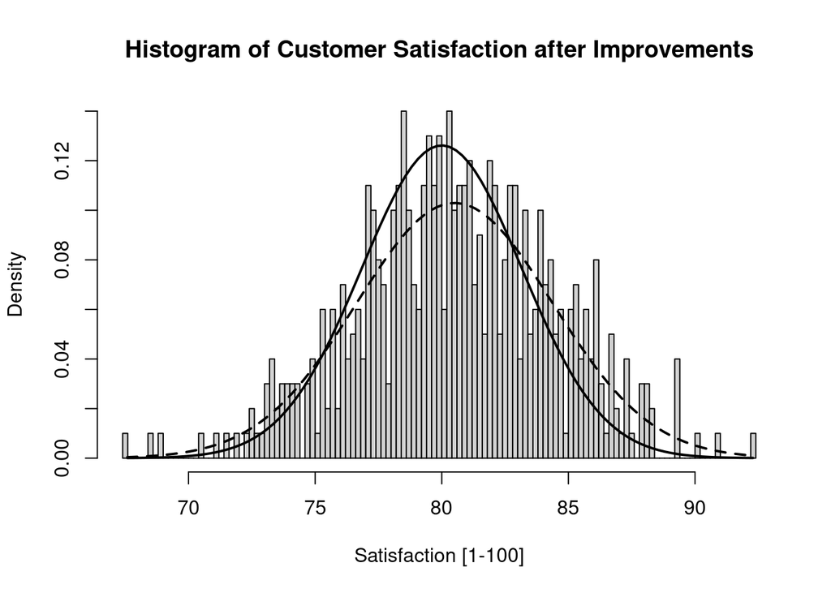

```r
mu2 <- mean(satisfaction)
sigma2 <- sd(satisfaction)
xj <- seq(min(satisfaction), max(satisfaction), length = 100)
f1j <- dnorm(xj, mean = mu_optj, sd = sigma_optj)
f2j <- dnorm(xj, mean = mu2, sd = sigma2)
hist(satisfaction,main = "Histogram of Customer Satisfaction after Improvements", xlab = "Satisfaction [1-100]",
     breaks = 100, probability = T)
lines(xj,f1j,type="l",lwd=2,lty=1)
lines(xj,f2j,type="l",lwd=2,lty=2)
abline(v=LSL2,lwd=2,lty=2)
```

# 6 End - Further analysis

By selecting only one company for the phone shipments and one material supplier the following aspects remain to be considered:

- Delivery company 1 is a bit more costly, as well as the selected screen glass supplier.
- With the improved customer satisfaction, the sales are expected to increase significantly.
- This still to be confirmed increase of sales should surpass greatly the increased cost of the abovementioned changes in delivery and screen glass supplier companies.

A further analysis is scheduled in 6 months after the implementation of the changes, to confirm and assess the success of the applied six sigma methodology.